# Tidy Modelling with R

# 1 Tidyverse Workflow

Main steps:

1. Read the data
2. Clean the data
3. Explore the data
4. Statistical modelling
5. Communicate the results and findings

## 1.1 Types of Data Science Research Problems

1. Descriptive
2. Exploratory
3. Inferential
4. Predictive

# 2 Modeling Workflow

1. Data analysis
2. Feature engineering
3. Model fitting
4. Hyper parameter tuning
5. Model evaluation

# 3 Tiydmodels Ecosystem

`tidymodels`: a collection of R packages for modeling and machine learning

[figure not shown]

Image source: https://rpubs.com/chenx/tidymodels_tutorial

# 4 Tidymodels packages

1. `rsamples` - to split the data into training and testing sets (as well as cross validation sets, etc.)
2. `recipes` - to prepare the data with preprocessing (assign variables and preprocessing steps)
3. `parsnip` - to specify and fit the data to a model
4. `yardstick` and `tune` - to evaluate model performance
5. `workflows` - combining recipe and parsnip objects into a workflow ( makes it easier to keep track of what you have done)
6. `tune` and `dials` - model optimization
7. `broom` - to make the output from fitting a model easier to read

# 5 Loading `tidyverse`

```r
library(tidyverse)
```

# 6 Loading `tidymodels`

```r
library(tidymodels)
```

# 7 `rsample` package

Can be used to create training and test data sets

- initial_split()
- training()
- testing()

## 7.1 Example

```r
library(palmerpenguins)
data(penguins)
dim(penguins)
```

```
## [1] 344   8
```

```r
# 80% of the data to the training set and the remaining 20% for testing
penguins_split <- initial_split(penguins, prop = 0.80)
training_p <- training(penguins_split)
dim(training_p)
```

```
## [1] 275   8
```

```r
test_p <- testing(penguins_split)
dim(test_p)
```

```
## [1] 69  8
```

When there is a class imbalance we can use `strata` arg in initial_split() ensure that the random split with similar distribution of response variable.

```r
library(MLDataR)
glimpse(MLDataR::thyroid_disease)
```

```
## Rows: 3,772
## Columns: 28
## $ ThryroidClass                  <chr> "negative", "negative", "negative", "ne…
## $ patient_age                    <int> 41, 23, 46, 70, 70, 18, 59, 80, 66, 68,…
## $ patient_gender                 <dbl> 1, 1, 0, 1, 1, 1, 1, 1, 1, 0, 1, 1, 1, …
## $ presc_thyroxine                <dbl> 0, 0, 0, 1, 0, 1, 0, 0, 0, 0, 0, 1, 0, …
## $ queried_why_on_thyroxine       <dbl> 0, 0, 0, 0, 0, 0, 0, 0, 0, 0, 0, 0, 0, …
## $ presc_anthyroid_meds           <dbl> 0, 0, 0, 0, 0, 0, 0, 0, 0, 0, 0, 0, 0, …
## $ sick                           <dbl> 0, 0, 0, 0, 0, 0, 0, 0, 0, 0, 0, 0, 1, …
## $ pregnant                       <dbl> 0, 0, 0, 0, 0, 0, 0, 0, 0, 0, 0, 0, 0, …
## $ thyroid_surgery                <dbl> 0, 0, 0, 0, 0, 0, 0, 0, 0, 0, 0, 0, 0, …
## $ radioactive_iodine_therapyI131 <dbl> 0, 0, 0, 0, 0, 0, 0, 0, 0, 0, 0, 0, 0, …
## $ query_hypothyroid              <dbl> 0, 0, 0, 0, 0, 0, 0, 0, 0, 0, 0, 0, 0, …
## $ query_hyperthyroid             <dbl> 0, 0, 0, 0, 0, 0, 0, 0, 0, 0, 0, 0, 1, …
## $ lithium                        <dbl> 0, 0, 0, 0, 0, 0, 0, 0, 0, 0, 0, 0, 0, …
## $ goitre                         <dbl> 0, 0, 0, 0, 0, 0, 0, 0, 0, 0, 0, 0, 0, …
## $ tumor                          <dbl> 0, 0, 0, 0, 0, 0, 0, 0, 1, 0, 1, 0, 0, …
## $ hypopituitarism                <dbl> 0, 0, 0, 0, 0, 0, 0, 0, 0, 0, 0, 0, 0, …
## $ psych_condition                <dbl> 0, 0, 0, 0, 0, 0, 0, 0, 0, 0, 0, 0, 0, …
## $ TSH_measured                   <dbl> 1, 1, 1, 1, 1, 1, 0, 1, 1, 1, 1, 1, 1, …
## $ TSH_reading                    <dbl> 1.30, 4.10, 0.98, 0.16, 0.72, 0.03, NA,…
## $ T3_measured                    <dbl> 1, 1, 0, 1, 1, 0, 0, 1, 1, 1, 1, 0, 1, …
## $ T3_reading                     <dbl> 2.5, 2.0, NA, 1.9, 1.2, NA, NA, 0.6, 2.…
## $ T4_measured                    <dbl> 1, 1, 1, 1, 1, 1, 1, 1, 1, 1, 1, 1, 1, …
## $ T4_reading                     <dbl> 125, 102, 109, 175, 61, 183, 72, 80, 12…
## $ thyrox_util_rate_T4U_measured  <dbl> 1, 0, 1, 0, 1, 1, 1, 1, 1, 1, 1, 1, 1, …
## $ thyrox_util_rate_T4U_reading   <dbl> 1.14, NA, 0.91, NA, 0.87, 1.30, 0.92, 0…
## $ FTI_measured                   <dbl> 1, 0, 1, 0, 1, 1, 1, 1, 1, 1, 1, 1, 1, …
## $ FTI_reading                    <dbl> 109, NA, 120, NA, 70, 141, 78, 115, 132…
## $ ref_src                        <chr> "SVHC", "other", "other", "other", "SVI…
```

```r
summary(as.factor(thyroid_disease$ThryroidClass))
```

```
## negative     sick
##     3541      231
```

```r
# Create a data split object
thyroiddata_split <- initial_split(
  thyroid_disease,
  prop = 0.8,
  # stratification by outcome variable
  strata = ThryroidClass
)

# Create the training data
thyroid_training <- thyroiddata_split %>% training()
head(thyroid_training)
```

```
##   ThryroidClass patient_age patient_gender presc_thyroxine
## 1      negative          41              1               0
## 2      negative          23              1               0
## 3      negative          46              0               0
## 4      negative          70              1               1
## 7      negative          59              1               0
## 8          sick          80              1               0
##   queried_why_on_thyroxine presc_anthyroid_meds sick pregnant thyroid_surgery
## 1                        0                    0    0        0               0
## 2                        0                    0    0        0               0
## 3                        0                    0    0        0               0
## 4                        0                    0    0        0               0
## 7                        0                    0    0        0               0
## 8                        0                    0    0        0               0
##   radioactive_iodine_therapyI131 query_hypothyroid query_hyperthyroid lithium
```

[output cut: 27 more lines]

```r
class(thyroid_training)
```

```
## [1] "data.frame"
```

```r
thyroid_training %>% nrow()
```

```
## [1] 3017
```

```r
summary(as.factor(thyroid_training$ThryroidClass))
```

```
## negative     sick
##     2838      179
```

```r
# Create the test data
thyroid_test <- thyroiddata_split %>% testing()
head(thyroid_test)
```

```
##    ThryroidClass patient_age patient_gender presc_thyroxine
## 5       negative          70              1               0
## 6       negative          18              1               1
## 12      negative          67              1               1
## 14      negative          59              1               0
## 27      negative          60              0               1
## 28      negative          25              1               0
##    queried_why_on_thyroxine presc_anthyroid_meds sick pregnant thyroid_surgery
## 5                         0                    0    0        0               0
## 6                         0                    0    0        0               0
## 12                        0                    0    0        0               0
## 14                        0                    0    0        0               0
## 27                        0                    0    0        0               0
## 28                        0                    0    0        0               0
##    radioactive_iodine_therapyI131 query_hypothyroid query_hyperthyroid lithium
```

[output cut: 27 more lines]

```r
thyroid_test %>% nrow()
```

```
## [1] 755
```

```r
summary(as.factor(thyroid_test$ThryroidClass))
```

```
## negative     sick
##      703       52
```

The `rsample` package can also be used to create resamples of a data set, such as cross-validation or the bootstrap

## 7.2 Bootstrap

```r
boot_samp <- rsample::bootstraps(penguins, times = 3)
boot_samp
```

```
## # Bootstrap sampling
## # A tibble: 3 × 2
##   splits            id
##   <list>            <chr>
## 1 <split [344/133]> Bootstrap1
## 2 <split [344/137]> Bootstrap2
## 3 <split [344/120]> Bootstrap3
```

## 7.3 k-fold Cross-validation

```r
set.seed(999)
# using rsample package
cv <- vfold_cv(training_p, v = 10)  #v is the number of folds
cv  #10 folds
```

```
## #  10-fold cross-validation
## # A tibble: 10 × 2
##    splits           id
##    <list>           <chr>
##  1 <split [247/28]> Fold01
##  2 <split [247/28]> Fold02
##  3 <split [247/28]> Fold03
##  4 <split [247/28]> Fold04
##  5 <split [247/28]> Fold05
##  6 <split [248/27]> Fold06
##  7 <split [248/27]> Fold07
##  8 <split [248/27]> Fold08
##  9 <split [248/27]> Fold09
## 10 <split [248/27]> Fold10
```

# 8 parsnip: Fitting a linear regression model

- Motivation
  - Package: MASS

    Function: lda

    Code: predict(obj)
  - Package: glm

    Function: stats

    Code: predict(obj, type=“response”)
- General interface for modelling
- Specifications: model, engine, fit

**Step 1: Model setup**

Inputs to the function

1. Model type (linear regression, random forest)

`linear_reg()`

`rand_forest()`

2. Specify engine (package implementation of algorithm)

`set_engine("name_of_the_package")`

3. Declare mode (classification vs linear regression)

`set_mode("regression")`

`set_mode("classification")`

```r
# model setup - linear model
lm_mod <- linear_reg() %>%
  set_engine("lm") %>%
  set_mode("regression")

lm_mod
```

```
## Linear Regression Model Specification (regression)
##
## Computational engine: lm
```

```r
## model setup - random forest

rf_mod_c <- rand_forest() %>%
  set_engine("randomForest") %>%
  set_mode("classification")

rf_mod_c
```

```
## Random Forest Model Specification (classification)
##
## Computational engine: randomForest
```

```r
rf_mod_r <- rand_forest() %>%
  set_engine("randomForest") %>%
  set_mode("regression")

rf_mod_r
```

```
## Random Forest Model Specification (regression)
##
## Computational engine: randomForest
```

**Step 2: Fitting model**

Example 1:

```r
lm_fit <- lm_mod %>%
  fit(body_mass_g ~ bill_length_mm + bill_depth_mm + flipper_length_mm + species + sex, data = training_p)

lm_fit
```

```
## parsnip model object
##
##
## Call:
## stats::lm(formula = body_mass_g ~ bill_length_mm + bill_depth_mm +
##     flipper_length_mm + species + sex, data = data)
##
## Coefficients:
##       (Intercept)     bill_length_mm      bill_depth_mm  flipper_length_mm
##          -1116.16              19.50              63.70              14.09
##  speciesChinstrap      speciesGentoo            sexmale
##           -274.13            1048.53             426.51
```

Example 2:

```r
rf_fit <- rf_mod_r %>%
  fit(body_mass_g ~ bill_length_mm + bill_depth_mm + flipper_length_mm + species + sex, data = training_p)

rf_fit
```

```
## parsnip model object
##
##
## Call:
##  randomForest(x = maybe_data_frame(x), y = y)
##                Type of random forest: regression
##                      Number of trees: 500
## No. of variables tried at each split: 1
##
##           Mean of squared residuals: 90177.76
##                     % Var explained: 86.6
```

Second format

```r
rf_randomForest <- rand_forest() %>%
  set_engine("randomForest") %>%
  set_mode("regression") %>%
  fit(body_mass_g ~ bill_length_mm + bill_depth_mm + flipper_length_mm + species + sex, data = training_p)

rf_randomForest
```

```
## parsnip model object
##
##
## Call:
##  randomForest(x = maybe_data_frame(x), y = y)
##                Type of random forest: regression
##                      Number of trees: 500
## No. of variables tried at each split: 1
##
##           Mean of squared residuals: 90476.73
##                     % Var explained: 86.56
```

Example 3

```r
# model
iris_fit1 <- decision_tree(mode =  "classification") %>%
  # engine
  set_engine("rpart") %>%
  # fit
  fit(Species ~ ., data = iris)
iris_fit1
```

```
## parsnip model object
##
## n= 150
##
## node), split, n, loss, yval, (yprob)
##       * denotes terminal node
##
## 1) root 150 100 setosa (0.33333333 0.33333333 0.33333333)
##   2) Petal.Length< 2.45 50   0 setosa (1.00000000 0.00000000 0.00000000) *
##   3) Petal.Length>=2.45 100  50 versicolor (0.00000000 0.50000000 0.50000000)
##     6) Petal.Width< 1.75 54   5 versicolor (0.00000000 0.90740741 0.09259259) *
##     7) Petal.Width>=1.75 46   1 virginica (0.00000000 0.02173913 0.97826087) *
```

```r
# model2
iris_fit2 <- decision_tree(mode =  "classification") %>%
  # engine
  set_engine("C5.0") %>%
  # fit
  fit(Species ~ ., data = iris)
iris_fit2
```

[output not shown]

Example 4

```r
# Specify a logistic regression model
logistic_model <- logistic_reg() %>%
  # Set the engine
  set_engine("glm") %>%
  # Set the mode
  set_mode("classification")

# Fit to training data
logistic_fit <- logistic_model %>%
  fit(
    sex ~ body_mass_g + flipper_length_mm ,
    data = training_p
  )

# Print model fit object
logistic_fit
```

```
## parsnip model object
##
##
## Call:  stats::glm(formula = sex ~ body_mass_g + flipper_length_mm, family = stats::binomial,
##     data = data)
##
## Coefficients:
##       (Intercept)        body_mass_g  flipper_length_mm
##          7.348711           0.002829          -0.095346
##
## Degrees of Freedom: 264 Total (i.e. Null);  262 Residual
##   (10 observations deleted due to missingness)
## Null Deviance:       366.7
## Residual Deviance: 293.4     AIC: 299.4
```

## 8.1 Making prediction - regression

```r
test_na_drop <- test_p %>% drop_na()
rf_pred <- rf_randomForest %>%
  predict(new_data = test_na_drop)
head(rf_pred)
```

```
## # A tibble: 6 × 1
##   .pred
##   <dbl>
## 1 3446.
## 2 3580.
## 3 3422.
## 4 3396.
## 5 4144.
## 6 3420.
```

## 8.2 Making prediction - classification

```r
# Predict outcome class
class_pred <- predict(
  logistic_fit,
  new_data = test_na_drop,
  type = "class"
)

class_pred %>% head()
```

```
## # A tibble: 6 × 1
##   .pred_class
##   <fct>
## 1 male
## 2 female
## 3 male
## 4 male
## 5 male
## 6 female
```

```r
# Obtain estimated probabilities for each outcome class level
prob_pred <- predict(
  logistic_fit,
  new_data = test_na_drop,
  type = "prob"
)

prob_pred %>% head()
```

```
## # A tibble: 6 × 2
##   .pred_female .pred_male
##          <dbl>      <dbl>
## 1        0.410      0.590
## 2        0.886      0.114
## 3        0.414      0.586
## 4        0.456      0.544
## 5        0.325      0.675
## 6        0.863      0.137
```

```r
# Combine test set results
pred_results <- test_na_drop %>%
  bind_cols(prob_pred, class_pred)

# View results tibble
pred_results %>%
  head()
```

```
## # A tibble: 6 × 11
##   species island bill_length_mm bill_depth_mm flipper_length_… body_mass_g sex
##   <fct>   <fct>           <dbl>         <dbl>            <int>       <int> <fct>
## 1 Adelie  Torge…           39.5          17.4              186        3800 fema…
## 2 Adelie  Torge…           40.3          18                195        3250 fema…
## 3 Adelie  Torge…           38.9          17.8              181        3625 fema…
## 4 Adelie  Torge…           36.6          17.8              185        3700 fema…
## 5 Adelie  Torge…           46            21.5              194        4200 male
## 6 Adelie  Dream            36.4          17                195        3325 fema…
## # … with 4 more variables: year <int>, .pred_female <dbl>, .pred_male <dbl>,
## #   .pred_class <fct>
```

## 8.3 Bind data and predictions

```r
test_pred <- test_na_drop %>%
  bind_cols(rf_pred)
head(test_pred)
```

```
## # A tibble: 6 × 9
##   species island bill_length_mm bill_depth_mm flipper_length_… body_mass_g sex
##   <fct>   <fct>           <dbl>         <dbl>            <int>       <int> <fct>
## 1 Adelie  Torge…           39.5          17.4              186        3800 fema…
## 2 Adelie  Torge…           40.3          18                195        3250 fema…
## 3 Adelie  Torge…           38.9          17.8              181        3625 fema…
## 4 Adelie  Torge…           36.6          17.8              185        3700 fema…
## 5 Adelie  Torge…           46            21.5              194        4200 male
## 6 Adelie  Dream            36.4          17                195        3325 fema…
## # … with 2 more variables: year <int>, .pred <dbl>
```

# 9 `yardstick`: Evaluvate Model Performance

input: tibble with predictions and actuals

## 9.1 Assessing model fit - regression

```r
# calculate RMSE
test_pred %>%
  rmse(truth = body_mass_g, estimate = .pred)
```

```
## # A tibble: 1 × 3
##   .metric .estimator .estimate
##   <chr>   <chr>          <dbl>
## 1 rmse    standard        306.
```

## 9.2 `coord_obs_pred()` function

Can be used in a ggplot to create scatterplot of prections vs actuals. In this scatterplot x- and y-axes have the same exact scale along with an aspect ratio of one.

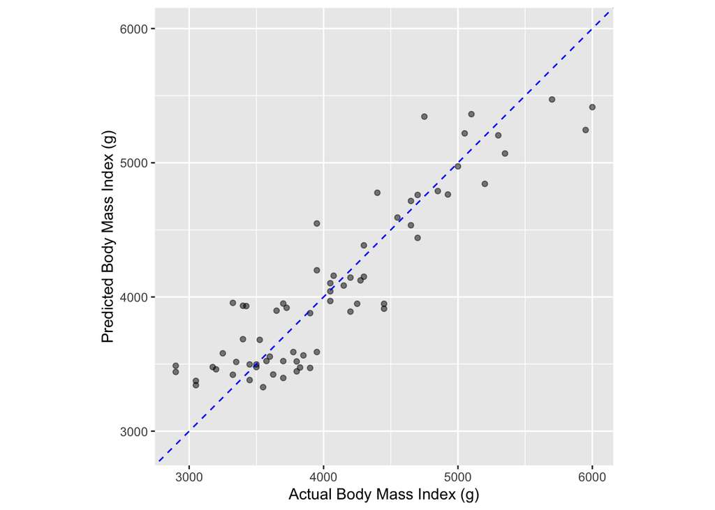

```r
test_pred %>%
  ggplot(aes(x = body_mass_g, y = .pred)) +
  geom_point(alpha = .5) +
  geom_abline(color = "blue", linetype = 2) +
  coord_obs_pred() +
  labs(x = "Actual Body Mass Index (g)", y = "Predicted Body Mass Index (g)")
```

## 9.3 Assessing model fit - classification

**Confusion matrix**

```r
# Calculate the confusion matrix
yardstick::conf_mat(
  pred_results,
  truth = sex,
  estimate =  .pred_class
)
```

```
##           Truth
## Prediction female male
##     female     27   12
##     male       12   17
```

```r
# Calculate the accuracy
yardstick::accuracy(
  pred_results,
  truth = sex,
  estimate =  .pred_class
)
```

```
## # A tibble: 1 × 3
##   .metric  .estimator .estimate
##   <chr>    <chr>          <dbl>
## 1 accuracy binary         0.647
```

```r
# Calculate the sensitivity
yardstick::sens(
  pred_results,
  truth = sex,
  estimate =  .pred_class
)
```

```
## # A tibble: 1 × 3
##   .metric .estimator .estimate
##   <chr>   <chr>          <dbl>
## 1 sens    binary         0.692
```

```r
# Calculate the specificity
yardstick::spec(
  pred_results,
  truth = sex,
  estimate =  .pred_class
)
```

```
## # A tibble: 1 × 3
##   .metric .estimator .estimate
##   <chr>   <chr>          <dbl>
## 1 spec    binary         0.586
```

## 9.4 Create a custom accuracy measure function to create several accuracy measures together

```r
error_measures <- metric_set(
  yardstick::accuracy,
  yardstick::sens,
  yardstick::spec
)


error_measures(
  pred_results,
  truth = sex,
  estimate =  .pred_class)
```

```
## # A tibble: 3 × 3
##   .metric  .estimator .estimate
##   <chr>    <chr>          <dbl>
## 1 accuracy binary         0.647
## 2 sens     binary         0.692
## 3 spec     binary         0.586
```

## 9.5 Confusion matrix

```r
confusion_matrix <- conf_mat(
  pred_results,
  truth = sex,
  estimate = .pred_class
)
confusion_matrix
```

```
##           Truth
## Prediction female male
##     female     27   12
##     male       12   17
```

```r
confusion_matrix %>%  summary()
```

```
## # A tibble: 13 × 3
##    .metric              .estimator .estimate
##    <chr>                <chr>          <dbl>
##  1 accuracy             binary         0.647
##  2 kap                  binary         0.279
##  3 sens                 binary         0.692
##  4 spec                 binary         0.586
##  5 ppv                  binary         0.692
##  6 npv                  binary         0.586
##  7 mcc                  binary         0.279
##  8 j_index              binary         0.279
##  9 bal_accuracy         binary         0.639
## 10 detection_prevalence binary         0.574
## 11 precision            binary         0.692
## 12 recall               binary         0.692
## 13 f_meas               binary         0.692
```

## 9.6 Visualizing confusion matrix

### 9.6.1 Heatmap

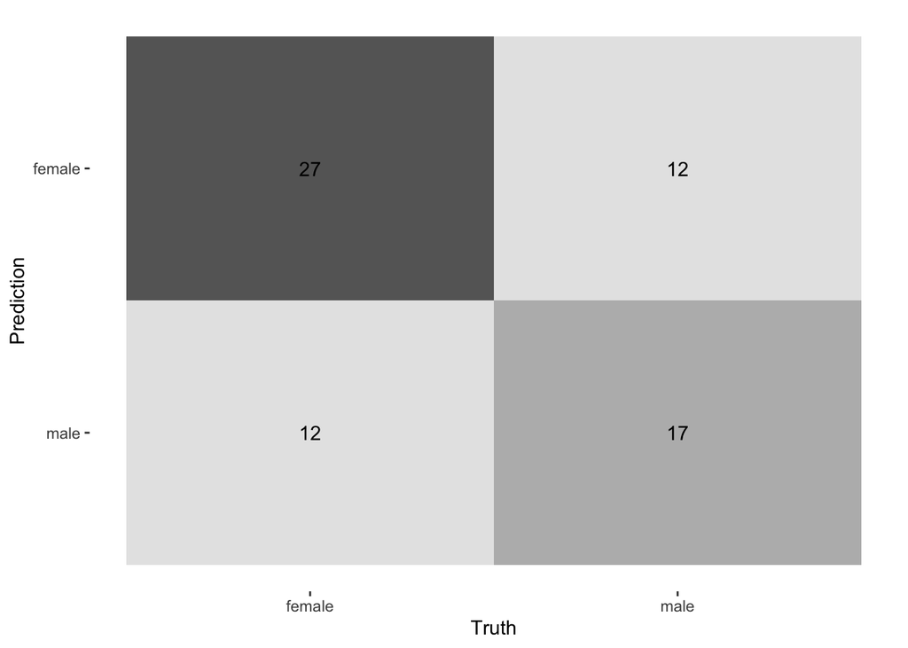

```r
conf_mat(
  pred_results,
  truth = sex,
  estimate = .pred_class
) %>%
  # Create a heat map
  autoplot(type = "heatmap")
```

### 9.6.2 Mosaic map

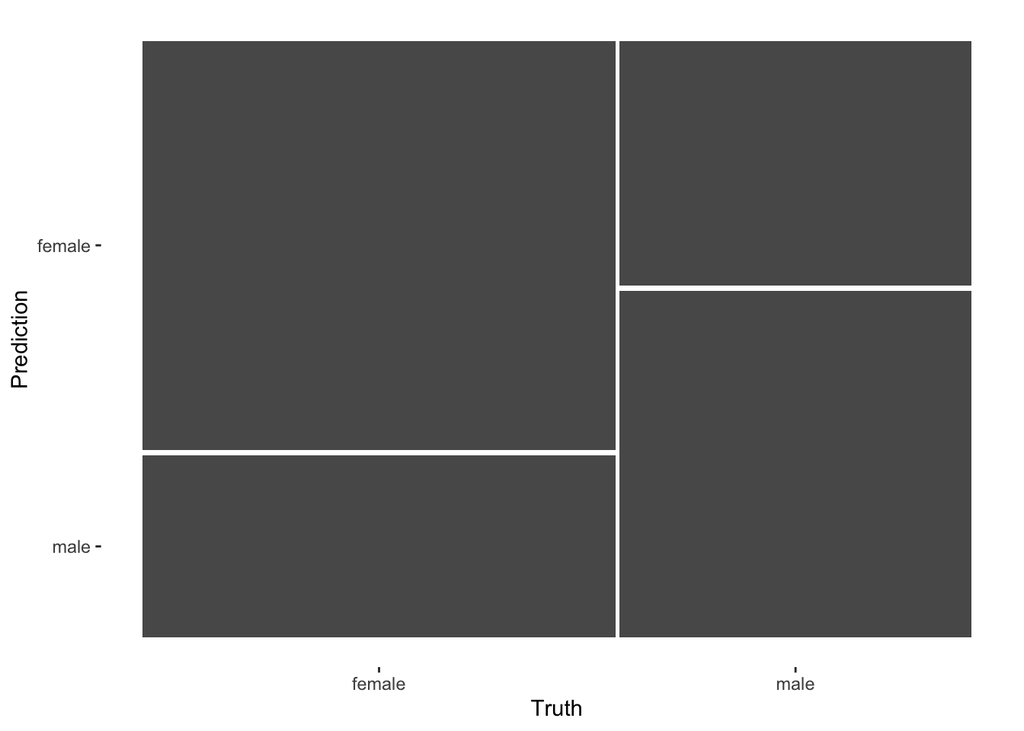

```r
conf_mat(
  pred_results,
  truth = sex,
  estimate = .pred_class
) %>%
  # Create a mosaic map
  autoplot(type = "mosaic")
```

### 9.6.3 ROC curve

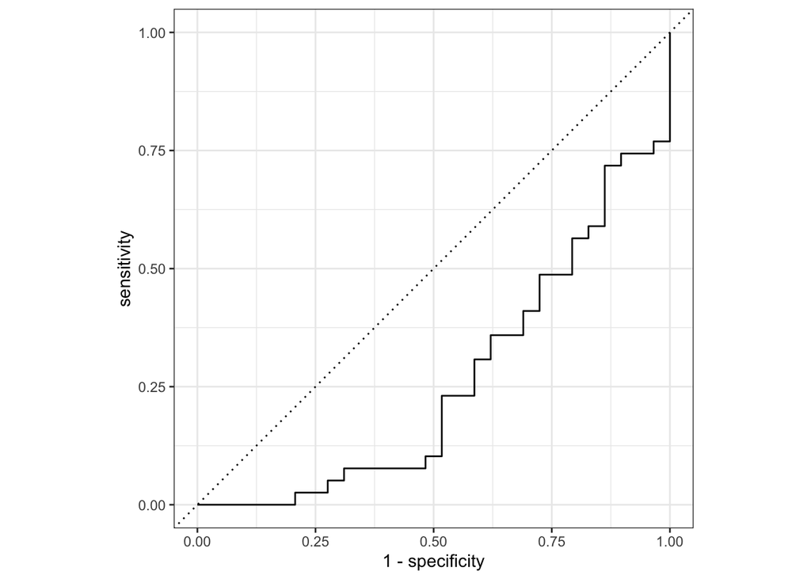

```r
# Plot ROC curve
pred_results %>%
  # Calculate metrics across thresholds
  roc_curve(
    truth = sex,
    estimate = .pred_male
  ) %>%
  autoplot()
```

### 9.6.4 Compute ROC AUC

```r
pred_results %>%
  roc_auc(
    truth = sex,
    estimate = .pred_female
  )
```

```
## # A tibble: 1 × 3
##   .metric .estimator .estimate
##   <chr>   <chr>          <dbl>
## 1 roc_auc binary         0.738
```

# 10 Feature Engineering with recipes

`recipes` package provides a pre-processing interface.

1. **Get the ingredients:** specify the response variable and predictor variables
2. Pre-processing: `step_*`

   `step_center()`

   `step_scale()`

   `step_log()`

   For more information [click here](https://recipes.tidymodels.org/reference/index.html).
3. Provide datasets for recipe steps: `prep`
4. Apply pre-processing: `bake`

## 10.1 Example

Step 1: Define our `recipe`

```r
iris_rec <- recipe(Species ~ ., data = iris)
iris_rec
```

```
## Recipe
##
## Inputs:
##
##       role #variables
##    outcome          1
##  predictor          4
```

Step 2: Pre-processing

```r
iris_steps <- iris_rec %>%
  # normalize numeric data to have a mean of zero
  step_center(all_numeric()) %>%
# normalize numeric data to have a standard deviation of one.
  step_scale(all_predictors())
iris_steps
```

```
## Recipe
##
## Inputs:
##
##       role #variables
##    outcome          1
##  predictor          4
##
## Operations:
##
## Centering for all_numeric()
## Scaling for all_predictors()
```

Step 3: Preparing our recipe

```r
prepped <- prep(iris_steps)
prepped
```

```
## Recipe
##
## Inputs:
##
##       role #variables
##    outcome          1
##  predictor          4
##
## Training data contained 150 data points and no missing data.
##
## Operations:
##
## Centering for Sepal.Length, Sepal.Width, Petal.Length, Petal.... [trained]
## Scaling for Sepal.Length, Sepal.Width, Petal.Length, Petal.... [trained]
```

Step 4: Obtain pre-processed dataset

```r
bake(prepped, head(iris))
```

```
## # A tibble: 6 × 5
##   Sepal.Length Sepal.Width Petal.Length Petal.Width Species
##          <dbl>       <dbl>        <dbl>       <dbl> <fct>
## 1       -0.898      1.02          -1.34       -1.31 setosa
## 2       -1.14      -0.132         -1.34       -1.31 setosa
## 3       -1.38       0.327         -1.39       -1.31 setosa
## 4       -1.50       0.0979        -1.28       -1.31 setosa
## 5       -1.02       1.25          -1.34       -1.31 setosa
## 6       -0.535      1.93          -1.17       -1.05 setosa
```

# 11 Missing value imputation with `recipes`

```r
data("credit_data", package = "modeldata")

## missing data per column
vapply(credit_data, function(x) mean(is.na(x)), c(num = 0))
```

```
##       Status    Seniority         Home         Time          Age      Marital
## 0.0000000000 0.0000000000 0.0013471037 0.0000000000 0.0000000000 0.0002245173
##      Records          Job     Expenses       Income       Assets         Debt
## 0.0000000000 0.0004490346 0.0000000000 0.0855410867 0.0105523125 0.0040413112
##       Amount        Price
## 0.0000000000 0.0000000000
```

```r
set.seed(342)
in_training <- sample(1:nrow(credit_data), 2000)

credit_tr <- credit_data[in_training, ]
credit_te <- credit_data[-in_training, ]
missing_examples <- c(14, 394, 565)

rec <- recipe(Price ~ ., data = credit_tr)

impute_rec <- rec %>%
  step_impute_mean(Income, Assets, Debt)

imp_models <- prep(impute_rec, training = credit_tr)

imputed_te <- bake(imp_models, new_data = credit_te, everything())

credit_te[missing_examples, ]
```

```
##      Status Seniority  Home Time Age Marital Records     Job Expenses Income
## 28     good        15 owner   36  43 married      no   fixed       75    251
## 688    good         2  rent   60  32 married      no partime       87    115
## 1002   good        21  rent   60  39 married      no   fixed      124    191
##      Assets Debt Amount Price
## 28     4000    0   1800  2557
## 688    2000    0   1250  1517
## 1002   2000    0   2000  2536
```

```r
imputed_te[missing_examples, names(credit_te)]
```

```
## # A tibble: 3 × 14
##   Status Seniority Home   Time   Age Marital Records Job     Expenses Income
##   <fct>      <int> <fct> <int> <int> <fct>   <fct>   <fct>      <int>  <int>
## 1 good          15 owner    36    43 married no      fixed         75    251
## 2 good           2 rent     60    32 married no      partime       87    115
## 3 good          21 rent     60    39 married no      fixed        124    191
## # … with 4 more variables: Assets <int>, Debt <int>, Amount <int>, Price <int>
```

```r
tidy(impute_rec, number = 1)
```

```
## # A tibble: 3 × 3
##   terms  model id
##   <chr>  <dbl> <chr>
## 1 Income    NA impute_mean_Hlm2y
## 2 Assets    NA impute_mean_Hlm2y
## 3 Debt      NA impute_mean_Hlm2y
```

```r
tidy(imp_models, number = 1)
```

```
## # A tibble: 3 × 3
##   terms  model id
##   <chr>  <dbl> <chr>
## 1 Income   142 impute_mean_Hlm2y
## 2 Assets  5378 impute_mean_Hlm2y
## 3 Debt     364 impute_mean_Hlm2y
```

# 12 Reference

- [Applied tidymodeling](https://josiahparry.com/slides/tidymodels/xaringan.html#1)
- [Building better training data](https://apreshill.github.io/tidymodels-it/slides/03-recipe.html#1)